# Impacts of COVID-19 and "shelter-in-place" order on the Lyft biking user behavior

## by Duy Pham

## Investigation Overview

> The overall goal is to understand the possible changes in the user behavior with the Lyft biking business in COVID-19. This analysis does not aim to produce a causal inference but focus on the potential consequences that we can observe in March, or more specifically, the later half of March 2020.

## Dataset Overview

> The dataset includes the following **13 variables**, with a total of **1,480,500 observations**.
> - Trip Duration (seconds)
> - Start Time and Date
> - End Time and Date
> - Start Station ID
> - Start Station Name
> - Start Station Latitude
> - Start Station Longitude
> - End Station ID
> - End Station Name
> - End Station Latitude
> - End Station Longitude
> - Bike ID
> - User Type (Subscriber or Customer – “Subscriber” = Member or “Customer” = Casual)

## Surpising drop in the biking sessions in March

> In March, there has been a surprising drop in the number of biking sessions, which is different from the increasing trend since the beginning of the year. While the figure in March is not that different from October, November and December last year, it raises a red flag about the observable impact of COVID-19 and the "shelter-in-place" order.

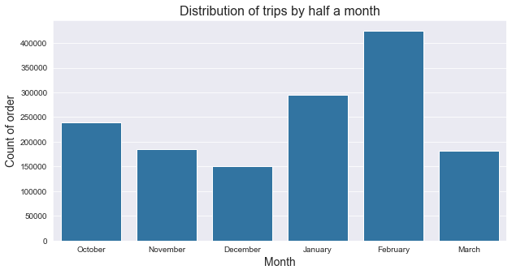

```python
plt.figure (figsize = (10,5))
base_color = sb.color_palette('Paired')[1]
sb.set_style('darkgrid')
sb.countplot(data=df, x='start_month', color=base_color)
plt.xlabel('Month', fontsize=14)
plt.ylabel('Count of order', fontsize=14)
plt.title("Distribution of trips by half a month", fontsize=16);
```

## Changing behavior of starting time: The high number of morning session is no longer there

> Looking at the graph, morning (7am - 9am) and afternoon (4pm-6pm) are the busiest time of the day in terms of bike riding. However, in March, there is a significantly visible drop in the distribution of people riding bike in the morning. It seems that because fewer people are going to work leads to the drop in the number of riding bike.

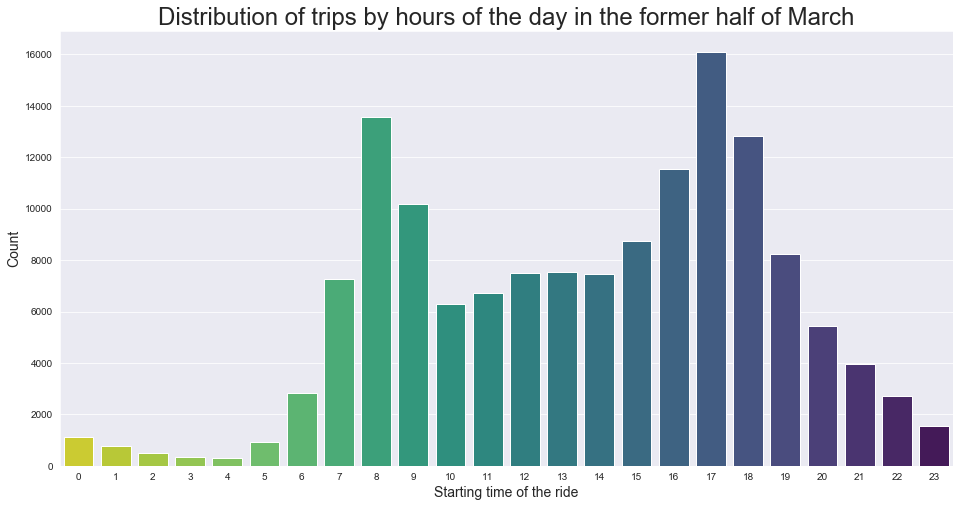

```python
# Visualizing distribution of trips by hours
plt.figure (figsize = (16,8))
sb.countplot(data=df[df['half-month']=='March - first'], x='start_hour', palette = 'viridis_r')
plt.xlabel('Starting time of the ride', fontsize=14)
plt.ylabel('Count', fontsize=14)
plt.title("Distribution of trips by hours of the day in the former half of March", fontsize=24);
```

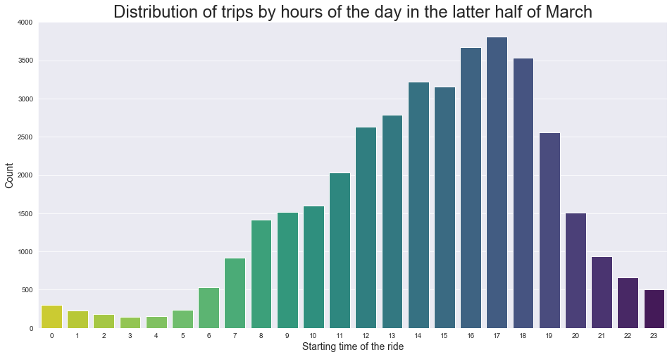

```python
# Visualizing distribution of trips by hours
plt.figure (figsize = (16,8))
sb.countplot(data=df[df['half-month']=='March - second'], x='start_hour', palette = 'viridis_r')
plt.xlabel('Starting time of the ride', fontsize=14)
plt.ylabel('Count', fontsize=14)
plt.title("Distribution of trips by hours of the day in the latter half of March", fontsize=24);
```

> As expected, at the latter half of March when the "shelter-in-place" took effect, there is a significant drop in the proportion of people riding a bike in the morning. The drop in the morning is highly correlated with the working time. Below are two hypotheses for further user study:
> 1. After the "shelter-in-place" took effect, people do not need to go to work. The assumption is that people often went to work by bike in the past, and probably, they walked back home after work. As long as they can work from home, they don't need to go to work with Lyft in the morning.
> 2. The biking is also for physical exercise purposes. When people can work from home, people basically have a more flexible schedule. For that reason, instead of waking up super early and biking in the morning so that they can go to the office on time, they can basically exercise at any time of the day. Thus, people decide to exercise equally over the day. but the traditional routine of biking in the afternoon as an exercise still remains.

> Before March, weekdays have the highest amount of ride requests. In March, Sunday, Tuesday and Monday have the highest amount of ride requests. For more specifically, there is a much significant drop in the number of subscribers compared to customers. In other words, subscribers do not have to go to the office to work on weekdays, but a number of them still go for exercise on Sunday (or because they feel sad for their subscription fee so they ride on Sunday).

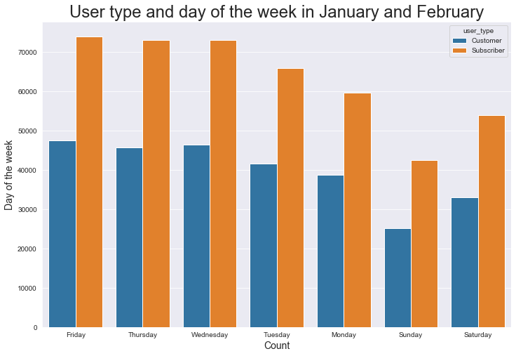

```python
#In January and February
plt.figure (figsize = (12,8))
sb.countplot(data=df[(df['start_month']=='January')|(df['start_month']=='February')], x='start_day_of_week', hue='user_type');
plt.xlabel('Count', fontsize=14)
plt.ylabel('Day of the week', fontsize=14)
plt.title("User type and day of the week in January and February", fontsize=24);
```

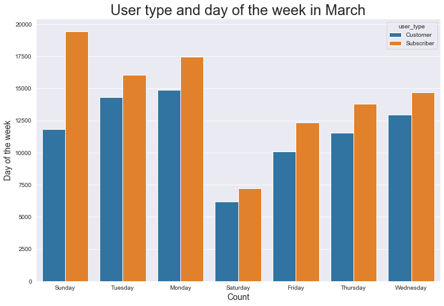

```python
#In March
plt.figure (figsize = (12,8))
sb.countplot(data=df[(df['start_month']=='March')], x='start_day_of_week', hue='user_type');
plt.xlabel('Count', fontsize=14)
plt.ylabel('Day of the week', fontsize=14)
plt.title("User type and day of the week in March", fontsize=24);
```

## The average session length stays the same

> The session length does not seem to be affected by the COVID-19 and "shelter-in-place" order. This is an expected finding. I don't think people will cut short their exercise, or relocate their destination because of this pandemic. Once they are out from home, they will travel as usual, thus, session length still stays the same.

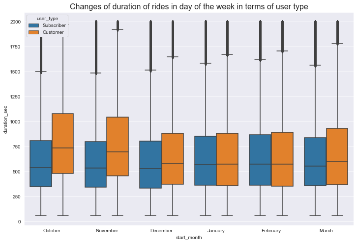

```python
plt.figure (figsize = (12,8))
sb.boxplot(data = df[df['duration_sec']<2000], x = 'start_month', y = 'duration_sec', hue = 'user_type')
plt.legend(loc = 2, framealpha = 1, title = 'user_type')
plt.title('Changes of duration of rides in day of the week in terms of user type', fontsize=16)
plt.show()
```

## Conclusion

> This finding is important for Lyft to identify the user behavior in times of pandemic. By understanding that most subscribers use Lyft biking to go to work, Lyft can provide additional function for the app (of course, when the pandemic is over), such as, pick up breakfast on the way to work. Optimizing the route and behavior of users will allow Lyft to come up with great ideas to support its customers.